# Introduction

For our first project, we analyzed crime patterns in Washington, DC, using data from the Open Data DC portal. The dataset, **Crime Incidents in 2023**, consists of 34,215 observations documenting reported crimes, including details on the type of offense, time of occurrence, geographic location, and methods involved.

Building on the insights from our initial analysis, this final project investigates the relationship between crime counts and environmental features, entertainment facilities, and population characteristics. By employing various modeling techniques, we aim to uncover patterns and develop actionable insights that can support effective urban planning and crime prevention strategies.

Building on the insights from our initial analysis, this final project fisrt SMART Question investigates the relationship between crime counts and key socioeconomic factors across the wards in Washington, DC:

**How do population density, median income, and poverty levels influence crime rates across the wards in Washington, DC?**

We selected these three factors because we are particularly interested in how these variables interact with crime rates. Additionally, we believe that they have a strong potential to explain variations in crime across the city. By exploring this relationship, we aim to provide actionable insights for policymakers and community stakeholders to address crime through targeted interventions and resource allocation.

# Factors of Interest

To address our SMART question, we focused on three key socioeconomic factors: **population density**, **median income**, and **poverty levels**. These factors were selected because of their strong theoretical and empirical connections to crime rates, as shown in prior research.

## Population Density

Population density refers to the number of people living per square mile in each ward. High population density often correlates with increased social interactions, which can influence both the likelihood of criminal activities and the reporting of crimes. Understanding its impact helps identify whether densely populated areas in Washington, DC, experience higher crime rates.

## Median Income

Median income represents the midpoint of income distribution in a ward. Income levels are often linked to access to resources, social mobility, and economic inequality. We hypothesize that wards with lower median incomes may exhibit higher crime rates due to economic stressors and limited opportunities.

## Poverty Levels

Poverty levels indicate the percentage of individuals living below the poverty line in each ward. Poverty is frequently associated with social disadvantages that can contribute to criminal behavior, such as lack of education, unemployment, and inadequate housing. Exploring poverty’s relationship to crime rates can reveal patterns crucial for community-level interventions.

# Crime Counts and Initial Observations

In the first part of our project, we analyzed crime counts across the wards in Washington, DC. To remind students, **Ward 5 had the highest crime counts**, while **Ward 3 was the safest** with the fewest crime counts.

```r
library(dplyr)
library(tidyr)
```

```r
library(ggplot2)
crime_data <- read.csv("/Users/halimaalbalushi/Desktop/CRIMES in DC/Final Project/Crime_Incidents.csv")
ward_data <- read.csv("/Users/halimaalbalushi/Desktop/CRIMES in DC/Final Project/Ward_Boundaries.csv")

crime_data_cleaned <- crime_data %>%
  filter(!is.na(WARD) & !is.na(OFFENSE) & !is.na(SHIFT)) %>%
  mutate(WARD = as.factor(WARD))

ward_data_cleaned <- ward_data %>%
  mutate(WARD = as.factor(WARD))

crime_ward_data <- crime_data_cleaned %>%
  left_join(ward_data_cleaned, by = "WARD")

summary(crime_ward_data)
```

```
##        X                Y               CCN            REPORT_DAT
##  Min.   :390262   Min.   :127432   Min.   : 5008224   Length:34211
##  1st Qu.:397265   1st Qu.:136120   1st Qu.:23060938   Class :character
##  Median :399074   Median :137847   Median :23117629   Mode  :character
##  Mean   :399304   Mean   :137732   Mean   :23131418
##  3rd Qu.:401136   3rd Qu.:139737   3rd Qu.:23172889
##  Max.   :407807   Max.   :147293   Max.   :92251156
##
##     SHIFT              METHOD            OFFENSE             BLOCK
##  Length:34211       Length:34211       Length:34211       Length:34211
##  Class :character   Class :character   Class :character   Class :character
##  Mode  :character   Mode  :character   Mode  :character   Mode  :character
##
##
##
##
##      XBLOCK           YBLOCK            WARD          ANC
##  Min.   :390262   Min.   :127432   5      :5629   Length:34211
##  1st Qu.:397265   1st Qu.:136120   2      :5469   Class :character
##  Median :399074   Median :137847   1      :5237   Mode  :character
##  Mean   :399304   Mean   :137732   7      :4569
##  3rd Qu.:401136   3rd Qu.:139737   6      :4281
##  Max.   :407807   Max.   :147293   8      :3822
##                                    (Other):5204
##     DISTRICT         PSA        NEIGHBORHOOD_CLUSTER BLOCK_GROUP
##  Min.   :1.00   Min.   :101.0   Length:34211         Length:34211
##  1st Qu.:2.00   1st Qu.:208.0   Class :character     Class :character
##  Median :4.00   Median :401.0   Mode  :character     Mode  :character
##  Mean   :3.75   Mean   :379.6
##  3rd Qu.:5.00   3rd Qu.:506.0
##  Max.   :7.00   Max.   :708.0
##  NA's   :284    NA's   :297
##   CENSUS_TRACT    VOTING_PRECINCT       LATITUDE       LONGITUDE
##  Min.   :   101   Length:34211       Min.   :38.81   Min.   :-77.11
##  1st Qu.:  3701   Class :character   1st Qu.:38.89   1st Qu.:-77.03
##  Median :  7202   Mode  :character   Median :38.91   Median :-77.01
##  Mean   :  7688                      Mean   :38.91   Mean   :-77.01
##  3rd Qu.:  9102                      3rd Qu.:38.93   3rd Qu.:-76.99
##  Max.   :980000                      Max.   :38.99   Max.   :-76.91
##  NA's   :11
```

[output cut: 17 more lines]

```
##  Min.   :77904   Min.   : 7.60   Min.   :26.80   Min.   :79.30
##  1st Qu.:79448   1st Qu.:11.30   1st Qu.:53.20   1st Qu.:87.80
##  Median :86071   Median :12.40   Median :59.00   Median :88.10
##  Mean   :83914   Mean   :15.28   Mean   :61.86   Mean   :88.91
##  3rd Qu.:89628   3rd Qu.:15.60   3rd Qu.:80.60   3rd Qu.:93.30
##  Max.   :89870   Max.   :27.70   Max.   :88.00   Max.   :94.50
##
##    Disability        Owner           Renter        Med_Income
##  Min.   : 7.30   Min.   :23.90   Min.   :38.50   Min.   : 48609
##  1st Qu.: 7.90   1st Qu.:35.40   1st Qu.:53.70   1st Qu.: 92398
##  Median :10.30   Median :38.20   Median :61.80   Median :115068
##  Mean   :10.91   Mean   :40.76   Mean   :59.24   Mean   :103352
##  3rd Qu.:12.60   3rd Qu.:46.30   3rd Qu.:64.60   3rd Qu.:128048
##  Max.   :16.70   Max.   :61.50   Max.   :76.10   Max.   :141393
##
```

```r
crime_summary <- crime_data_cleaned %>%
  group_by(WARD) %>%
  summarise(Total_Crimes = n(), .groups = "drop")

ward_summary <- ward_data_cleaned %>%
  select(WARD, Total_pop) %>%
  left_join(crime_summary, by = "WARD") %>%
  replace_na(list(Total_Crimes = 0))

ward_summary <- ward_summary %>%
  mutate(Crime_Rate_Per_Capita = Total_Crimes / Total_pop)

ward_summary
```

```
##   WARD Total_pop Total_Crimes Crime_Rate_Per_Capita
## 1    8     87043         3822            0.04390933
## 2    6     80772         4281            0.05300104
## 3    7     89870         4569            0.05084010
## 4    2     77904         5469            0.07020179
## 5    1     79448         5237            0.06591733
## 6    5     89628         5629            0.06280403
## 7    3     79851         2069            0.02591076
## 8    4     86071         3135            0.03642342
```

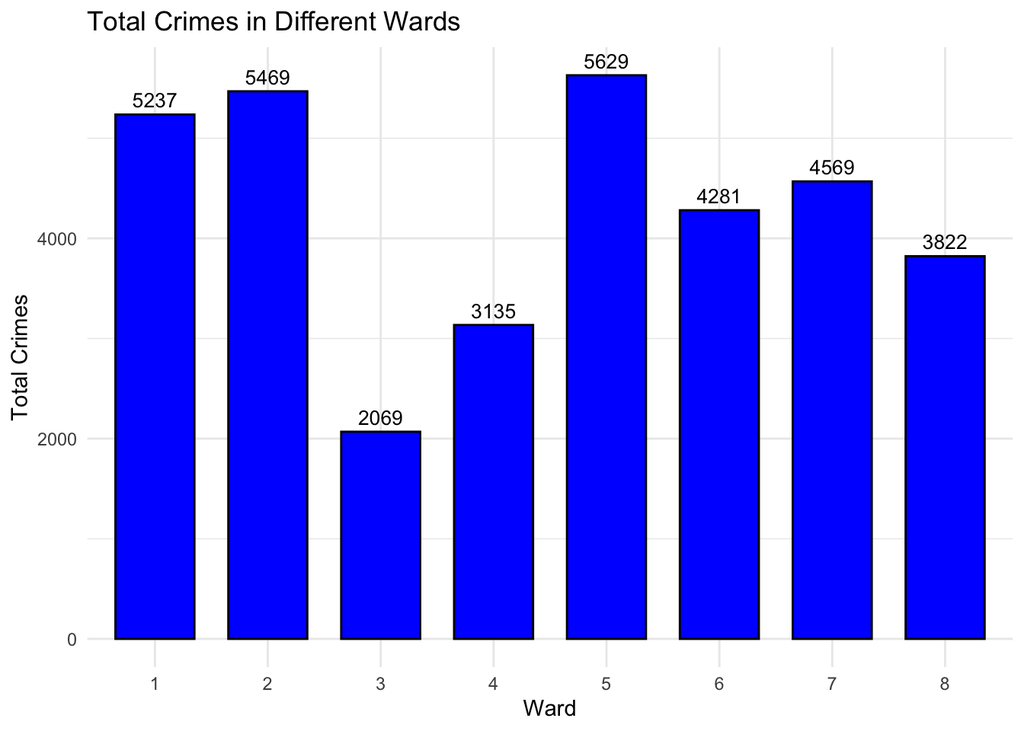

```r
#Crime count per Ward:
ggplot(ward_summary, aes(x = as.factor(WARD), y = Total_Crimes)) +
  geom_bar(stat = "identity", fill = "blue", color = "black", width = 0.7) +
  geom_text(aes(label = Total_Crimes), vjust = -0.5, size = 3.5) +
  labs(title = "Total Crimes in Different Wards",
       x = "Ward",
       y = "Total Crimes") +
  theme_minimal()
```

## Exploratory Data Analysis (EDA)

### Population Across Wards

Through our EDA, we found that all wards have over 75,000 residents. The **second-highest population** was in Ward 5, which aligns with its high crime counts. However, the **least populated ward**, Ward 2, surprisingly had the second-highest crime counts. This unexpected result suggests that population alone does not fully explain crime rates.

```r
population_summary <- crime_ward_data %>%
  group_by(WARD) %>%
  summarise(
    Total_Crimes = n(),
    Total_Population = mean(Total_pop, na.rm = TRUE)
  )
```

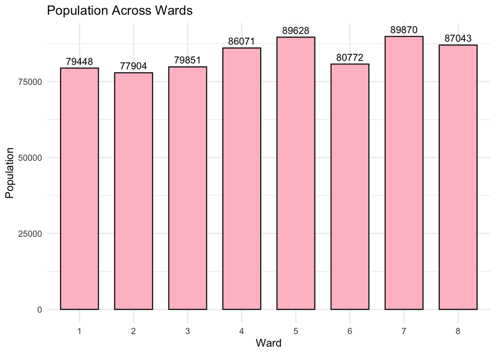

```r
ggplot(population_summary, aes(x = as.factor(WARD), y = Total_Population)) +
  geom_bar(stat = "identity", fill = "pink", color = "black", width = 0.7) +
  geom_text(aes(label = round(Total_Population)), vjust = -0.5, size = 3.5) +
  labs(title = "Population Across Wards",
       x = "Ward",
       y = "Population") +
  theme_minimal()
```

### Median Income Across Wards

From our analysis, **Ward 5 had one of the three lowest median incomes** despite its high population and crime counts. However, **Ward 3, which had the fewest crimes, had the highest median income**, supporting the hypothesis that higher income might be linked to fewer crimes. Interestingly, **Ward 8**, which had the lowest median income, did not have as many crime counts as expected, further complicating the relationship between income and crime.

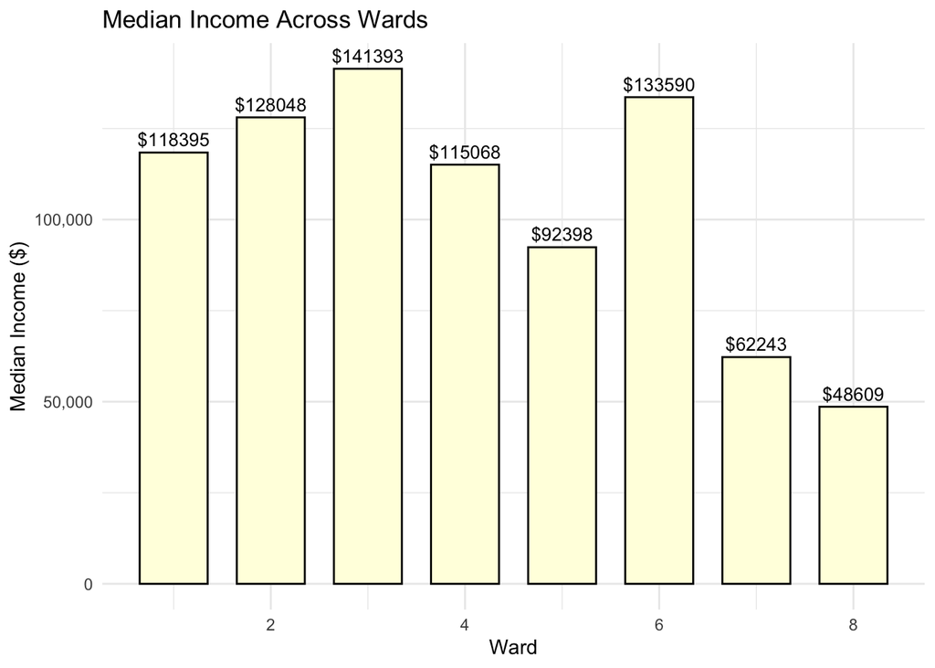

```r
#Median Income
library(scales)

ggplot(ward_data, aes(x = WARD, y = Med_Income)) +
  geom_bar(stat = "identity", fill = "lightyellow", color = "black", width = 0.7) +
  geom_text(aes(label = paste0("$", Med_Income)), vjust = -0.5, size = 3.5) +
  labs(
    title = "Median Income Across Wards",
    x = "Ward",
    y = "Median Income ($)"
  ) +
  scale_y_continuous(labels = comma) +
  theme_minimal()
```

### Poverty Levels Across Wards

Regarding poverty, **Ward 3 had the lowest poverty levels**, which aligns with its low crime counts. Conversely, **Ward 5 had the third-highest poverty levels**, which may partly explain its high crime counts. These patterns suggest some level of interaction between poverty and crime, but the relationship is not consistent across all wards.

```r
ward_summary <- crime_ward_data %>%
  group_by(WARD) %>%
  summarise(
    Total_Population = mean(Total_pop, na.rm = TRUE),
    Poverty = mean(Poverty, na.rm = TRUE)
  )
```

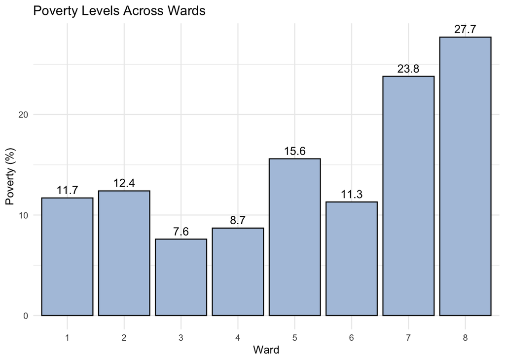

```r
# Poverty
ggplot(ward_summary, aes(x = factor(WARD), y = Poverty)) +
  geom_bar(stat = "identity", fill = "lightsteelblue", color = "black") +
  geom_text(aes(label = round(Poverty, 1)), vjust = -0.5, size = 4, color = "black") +
  labs(
    title = "Poverty Levels Across Wards",
    x = "Ward",
    y = "Poverty (%)"
  ) +
  theme_minimal()
```

## Correlation Analysis

We created a correlation plot to assess the associations between the factors (population, median income, poverty) and crime counts. The plot revealed **no strong relationships**—only weak or negligible correlations. This indicates that none of the factors we selected are strong predictors of crime counts in this dataset.

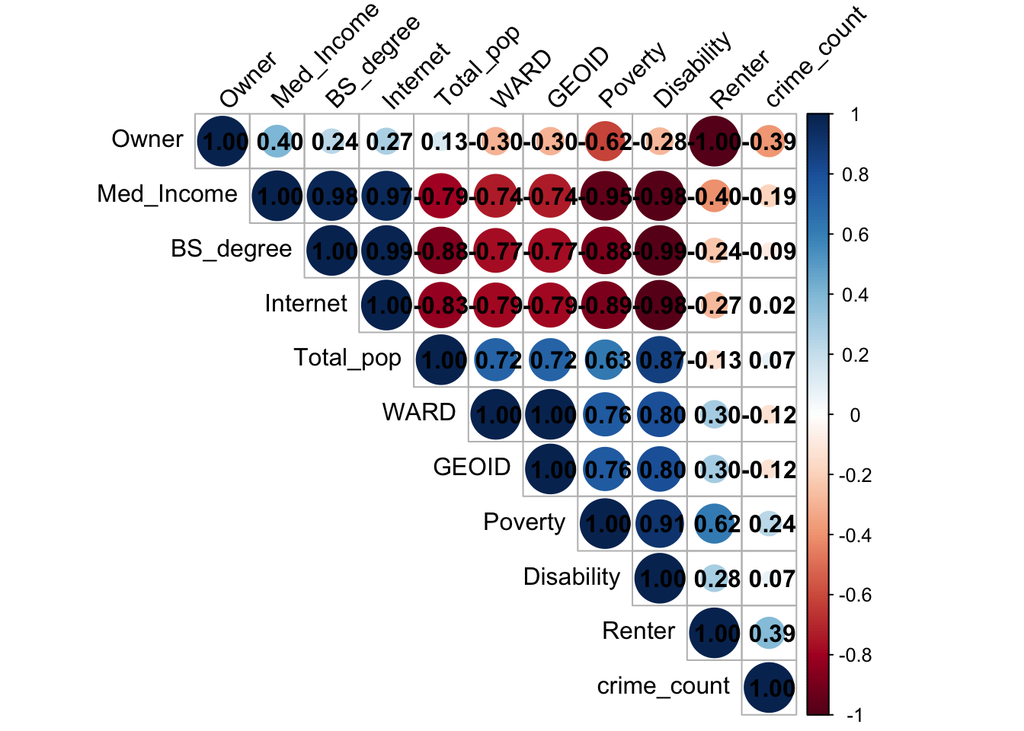

```r
crime_data <- read.csv("/Users/halimaalbalushi/Desktop/CRIMES in DC/Final Project/Crime_Incidents.csv")
ward_data <- read.csv("/Users/halimaalbalushi/Desktop/CRIMES in DC/Final Project/Ward_Boundaries.csv")


crime_count <- as.data.frame(table(crime_data$WARD))
colnames(crime_count) <- c("WARD", "crime_count")

crime_count$WARD <- as.numeric(as.character(crime_count$WARD))

ward_selected <- ward_data[, c("WARD", "GEOID", "NAME", "Total_pop",
                                     "Poverty", "BS_degree", "Internet",
                                     "Disability", "Owner", "Renter", "Med_Income")]


final_data <- merge(ward_selected, crime_count, by = "WARD", all.x = TRUE)


final_data$crime_count[is.na(final_data$crime_count)] <- 0


numeric_cols <- final_data[, sapply(final_data, is.numeric)]


correlation_matrix <- cor(numeric_cols, use = "complete.obs")


library(corrplot)
corrplot(correlation_matrix,
         method = "circle",  # Use circle style
         type = "upper",     # Show only upper triangle
         order = "hclust",   # Order variables by clustering
         tl.col = "black",   # Text color
         tl.srt = 45,        # Rotate labels
         addCoef.col = "black")  # Add correlation coefficients
```

## Linear Regression Model

To explore further, we built a linear regression model using these variables. However, the model produced: - A **negative R-squared value**, indicating poor fit. - A **high average p-value**, suggesting no significant predictors.

```r
# Load required libraries
library(car)  # For VIF calculation
# Load the dataset
crime_data <- read.csv("/Users/halimaalbalushi/Desktop/CRIMES in DC/Final Project/Crime_Incidents.csv")
ward_data <- read.csv("/Users/halimaalbalushi/Desktop/CRIMES in DC/Final Project/Ward_Boundaries.csv")

# Clean and preprocess data
crime_data$WARD <- as.numeric(gsub("\\D", "", crime_data$WARD))
crime_aggregated <- aggregate(crime_data$WARD, by = list(WARD = crime_data$WARD), FUN = length)
colnames(crime_aggregated) <- c("WARD", "crime_count")

# Merge datasets
ward_data_cleaned <- merge(ward_data_cleaned, crime_aggregated, by = "WARD", all.x = TRUE)
ward_data_cleaned$crime_count[is.na(ward_data_cleaned$crime_count)] <- 0


model <- lm(crime_count ~ Total_pop + Med_Income + Poverty, data = ward_data_cleaned)


summary(model)
```

```
##
## Call:
## lm(formula = crime_count ~ Total_pop + Med_Income + Poverty,
##     data = ward_data_cleaned)
##
## Residuals:
##        1        2        3        4        5        6        7        8
##  1147.12  1114.38 -1976.45  -598.63  1433.31   -87.47   -54.29  -977.96
##
## Coefficients:
##               Estimate Std. Error t value Pr(>|t|)
## (Intercept) -9.295e+02  3.860e+04  -0.024    0.982
## Total_pop    1.400e-02  2.845e-01   0.049    0.963
## Med_Income   2.046e-02  1.059e-01   0.193    0.856
## Poverty      1.270e+02  3.912e+02   0.325    0.762
##
## Residual standard error: 1569 on 4 degrees of freedom
## Multiple R-squared:  0.07501,    Adjusted R-squared:  -0.6187
## F-statistic: 0.1081 on 3 and 4 DF,  p-value: 0.951
```

```r
vif(model)
```

```
##  Total_pop Med_Income    Poverty
##   5.425923  36.996234  22.683448
```

The failure of our model was primarily due to the **small size of our second dataset**, which limited its explanatory power. With more time, we would have expanded our dataset to include crime data from all counties and wards across multiple states to ensure robust results.

## Conclusion for the first SMART Question:

Although our analysis did not yield a successful model, it provided valuable insights into the complexity of crime patterns. Future studies with larger datasets could better capture these relationships and provide actionable findings.